# Лабораторна робота №4. Задача кластеризації

**1. Будуємо графік паралельних координат, на якому кожному пацієнту відповідає окрема крива, що показує зміну показника в залежності від часу.**

```python
#імпортуємо бібліотеки NumPy, pandas та Matplotlib
import pandas as pd
import numpy as np
import seaborn as sns
import matplotlib.pyplot as plt
%matplotlib inline

from sklearn.cluster import KMeans
from sklearn.cluster import AgglomerativeClustering
from scipy.cluster.hierarchy import dendrogram, linkage
from sklearn.metrics import calinski_harabasz_score, davies_bouldin_score, silhouette_score
from sklearn.metrics import adjusted_rand_score
from matplotlib import pyplot as plt
import sys
```

Фізичний сенс даних: дані з листа являють собою заміри показника пульса пацієнтів через 3, 6, 12, 24, 36 та 48 годин з того моменту, як температура їх тіла досягла 32 градуси.

```python
#зчитуємо лист з таблиці під номером 12
df = pd.read_excel('data_lab4.xlsx', sheet_name='12', index_col=0)
df.dropna(inplace=True) #виключаємо рядки з пропусками та виводимо датафрейм
df
```

| Пульс (PS) | 3h | 6h | 12h | 24h | 36h | 48h |
| --- | --- | --- | --- | --- | --- | --- |
| 1 | 52 | 50 | 44 | 44 | 44 | 40 |
| 2 | 54 | 48 | 44 | 44 | 43 | 40 |
| 3 | 50 | 46 | 44 | 44 | 38 | 36 |
| 4 | 49 | 44 | 42 | 42 | 40 | 38 |
| 5 | 49 | 46 | 44 | 44 | 42 | 40 |
| 6 | 46 | 44 | 42 | 42 | 41 | 40 |
| 7 | 44 | 43 | 43 | 43 | 42 | 40 |
| 8 | 46 | 44 | 42 | 42 | 36 | 36 |
| 9 | 48 | 44 | 44 | 44 | 42 | 40 |
| 10 | 48 | 42 | 42 | 42 | 40 | 38 |
| 11 | 48 | 44 | 43 | 43 | 44 | 40 |
| 12 | 44 | 42 | 42 | 42 | 42 | 38 |
| 13 | 48 | 46 | 44 | 44 | 42 | 40 |
| 14 | 50 | 48 | 46 | 46 | 44 | 40 |
| 15 | 48 | 46 | 46 | 46 | 44 | 40 |
| 16 | 50 | 46 | 44 | 44 | 42 | 36 |
| 17 | 46 | 44 | 44 | 44 | 42 | 38 |
| 18 | 44 | 43 | 42 | 42 | 42 | 38 |
| 19 | 44 | 42 | 42 | 42 | 42 | 40 |
| 20 | 45 | 44 | 42 | 42 | 42 | 40 |
| 21 | 46 | 43 | 42 | 42 | 42 | 38 |
| 22 | 68 | 64 | 60 | 56 | 50 | 48 |
| 23 | 50 | 50 | 48 | 48 | 44 | 42 |
| 24 | 55 | 50 | 48 | 48 | 44 | 42 |
| 25 | 56 | 54 | 46 | 48 | 46 | 44 |
| 26 | 55 | 54 | 44 | 46 | 42 | 42 |
| 27 | 58 | 56 | 42 | 44 | 42 | 41 |
| 28 | 56 | 54 | 44 | 42 | 40 | 40 |
| 29 | 58 | 52 | 43 | 43 | 41 | 40 |

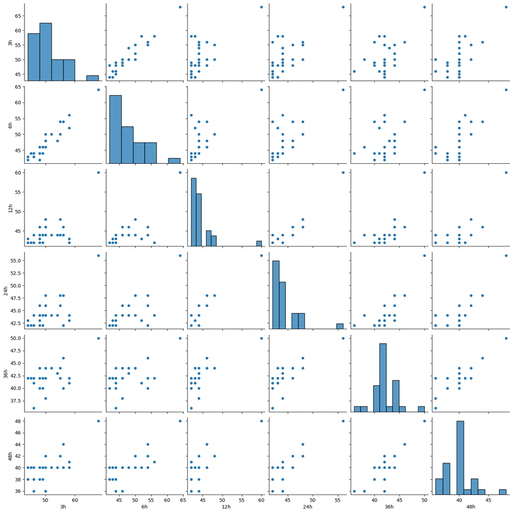

```python
#будуємо діаграму розсіювання для різних пар показників
sns.pairplot(df);
```

За діаграмою розсіювання можна виділити два кластери, проте для більш якісної оцінки даних замало.

```python
#копіюємо датафрейм та додаємо стовпець y_kmeans, що описує належність пацієнта певному кластеру при розбитті k-means
#всі об'єкти належать до однієї групи, стандартизація не потрібна
X = df.copy()
df['y_kmeans'] = 1 #всі пацієнти належать до одного кластера
df.head()
```

| Пульс (PS) | 3h | 6h | 12h | 24h | 36h | 48h | y_kmeans |
| --- | --- | --- | --- | --- | --- | --- | --- |
| 1 | 52 | 50 | 44 | 44 | 44 | 40 | 1 |
| 2 | 54 | 48 | 44 | 44 | 43 | 40 | 1 |
| 3 | 50 | 46 | 44 | 44 | 38 | 36 | 1 |
| 4 | 49 | 44 | 42 | 42 | 40 | 38 | 1 |
| 5 | 49 | 46 | 44 | 44 | 42 | 40 | 1 |

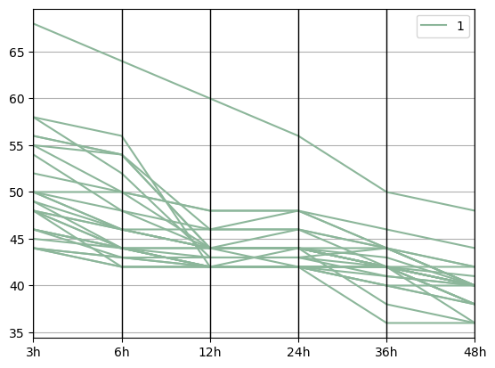

```python
#використовуємо метод паралельних ліній, коли для кожного рядка будується графік, що відображає динаміку зміни показника в часі
pd.plotting.parallel_coordinates(df,'y_kmeans', cols=X.columns) #cols - значення на графіку з таблиці
```

З графіку можна зробити висновок про наявність трьох кластерів.

**2. Розбиваємо пацієнтів на кластери за допомогою алгоритму k-середніх за різної кількості кластерів. Результати візуалізуємо на графіку паралельних координат, де лінії, що відповідають пацієнтам з різних кластерів, позначені різними кольорами.Оцінюємо оптимальну кількість кластерів для використаного алгоритму на основі індексу якості кластеризації (Calinski–Harabasz, Davies–Bouldin, Silhouette).**

Використовуємо алгоритм k-means++. Відповідно до нього, випадковим чином обирається центр першого кластера. Після цього, поки не буде обрано k кластерів, для кожного об'єкта обчислюється відстань до найближчого центра та обирається центр наступного кластера.

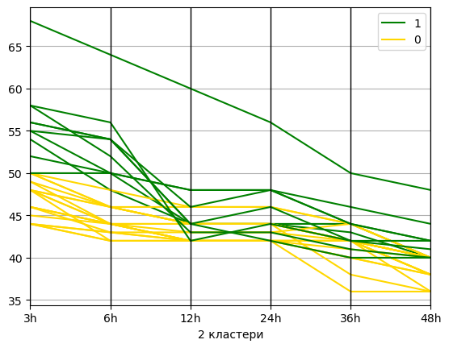

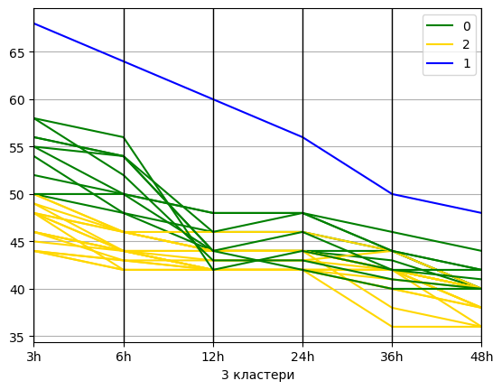

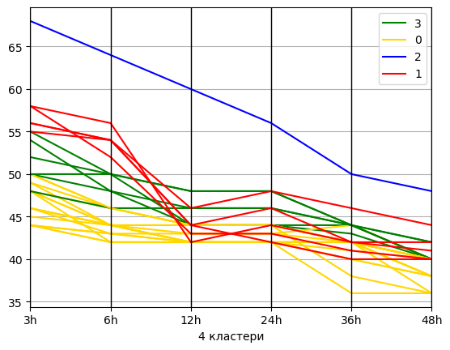

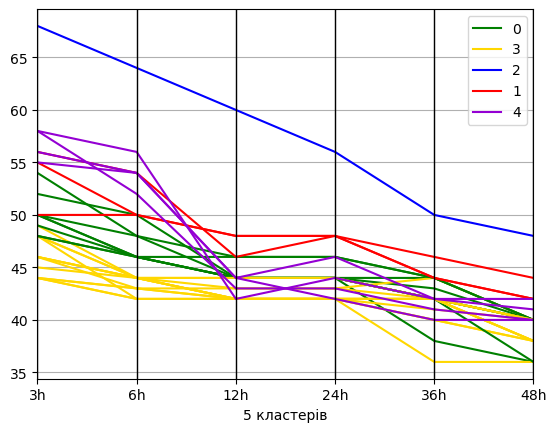

```python
#кластеризація алгоритмом k-means
#розбиваємо на 2, 3, 4, 5 кластерів

#2 кластери
kmeans = KMeans(n_clusters=2, init='k-means++')
kmeans.fit(X)
df['y_kmeans'] = kmeans.labels_ #мітки кластерів
colors = ('green', 'gold', 'blue', 'red', 'darkviolet')
pd.plotting.parallel_coordinates(df, 'y_kmeans', cols=X.columns, color=colors)
plt.xlabel('2 кластери')
plt.show()

df_kmeans_2 = df['y_kmeans'] #записуємо результат для подальшого порівняння

#3 кластери
kmeans = KMeans(n_clusters=3, init='k-means++')
kmeans.fit(X)
df['y_kmeans'] = kmeans.labels_ #мітки кластерів
colors = ('green', 'gold', 'blue', 'red', 'darkviolet')
pd.plotting.parallel_coordinates(df, 'y_kmeans', cols=X.columns, color=colors)
plt.xlabel('3 кластери')
plt.show()

df_kmeans_3 = df['y_kmeans']

#4 кластери
kmeans = KMeans(n_clusters=4, init='k-means++')
kmeans.fit(X)
df['y_kmeans'] = kmeans.labels_ #мітки кластерів
colors = ('green', 'gold', 'blue', 'red', 'darkviolet')
pd.plotting.parallel_coordinates(df, 'y_kmeans', cols=X.columns, color=colors)
plt.xlabel('4 кластери')
plt.show()

df_kmeans_4 = df['y_kmeans']

#5 кластерів
kmeans = KMeans(n_clusters=5, init='k-means++')
kmeans.fit(X)
df['y_kmeans'] = kmeans.labels_ #мітки кластерів
colors = ('green', 'gold', 'blue', 'red', 'darkviolet')
pd.plotting.parallel_coordinates(df, 'y_kmeans', cols=X.columns, color=colors)
plt.xlabel('5 кластерів')
plt.show()

df_kmeans_5 = df['y_kmeans']
```

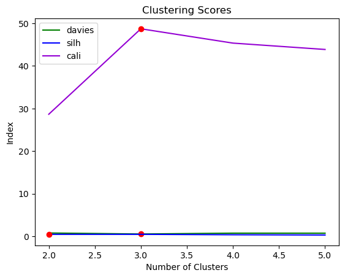

```python
# оцінюємо оптимальну кількість кластерів на основі індексів якості кластеризації
# для Calinski–Harabasz та Silhouette індекс має бути максимальним, для Davies–Bouldin - мінімальним

k_range = range(2, 6)  # 2, 3, 4, 5 кластерів
scores = {davies_bouldin_score: np.argmin, silhouette_score: np.argmax, calinski_harabasz_score: np.argmax}

handles=[]

for score, color in zip(scores.keys(), ['green', 'blue', 'darkviolet']):
    indices = []
    for k in k_range:
        labels = KMeans(n_clusters = k).fit_predict(X)
        indices.append(score(X, labels))
    plt.plot(k_range, indices, color=color)
    arg = scores[score](indices)
    plt.plot(k_range[arg], indices[arg], marker='o', c='r')
    handles.append(plt.Line2D([], [], color=color))
    indices.append(score.__name__)

plt.title('Clustering Scores')
plt.xlabel('Number of Clusters')
methods = ["davies", "silh", "cali"]
plt.ylabel('Index')
plt.legend(handles, methods)
plt.show()
```

Як бачимо з результатів оцінки на основі індексів, найкраще підходить розбиття на 3 кластери.

**3. Розбиваємо пацієнтів на кластери за допомогою алгоритму агломеративної кластеризації при зв'язках ward та average. Результати роботи подаємо у вигляді дендрограми. Оцінюємо розбиття на різні кількості кластерів та обираємо найкраще відповідно до графіку паралельних координат. Оцінюємо оптимальну кількість кластерів для на основі індексу якості кластеризації (Calinski–Harabasz, Davies–Bouldin, Silhouette).**

Алгоритм агломеративної кластеризації об’єднує пару кластерів вибіркових даних та використовує відстань з’єднання. Цей ієрархічний алгоритм використовує підхід "знизу-вгору", коли кожна точка має власний кластер, а потім при підйомі по ієрархії пари кластерів об'єднуються. Параметр ward мінімізує дисперсію об'єднаних кластерів.

```python
#додаємо стовпець y_agglo, що описує належність пацієнта певному кластеру при розбитті AgglomerativeClustering
df['y_agglo'] = 1
```

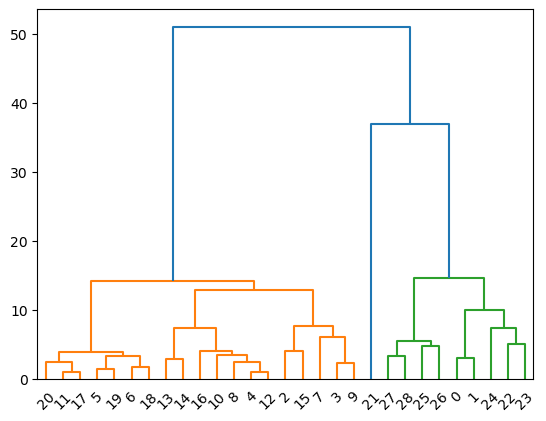

```python
#для побудови дендрограми використовуємо функцію dendrogram з модулю scipy.cluster.hierarchy
dendrogram(linkage(X, method='ward'));
```

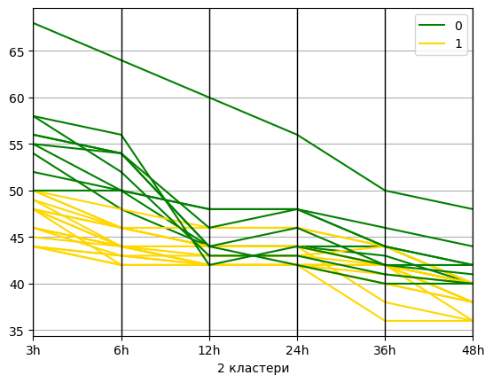

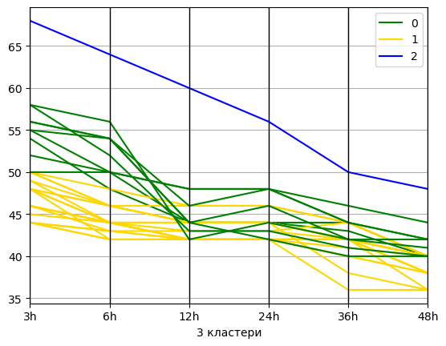

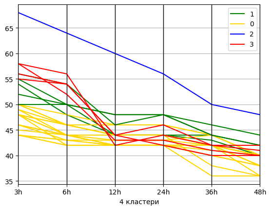

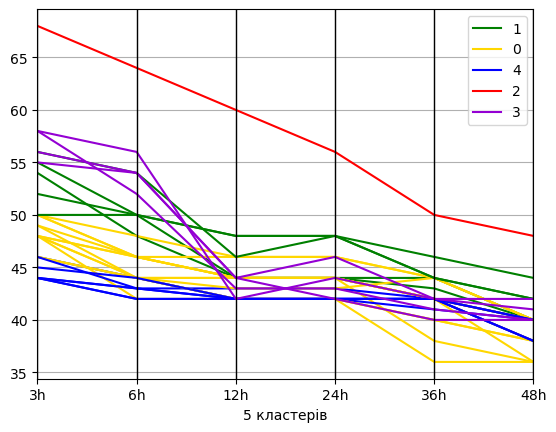

```python
#кластеризація алгоритмом AgglomerativeClustering з linkage = ward
#розбиваємо на 2, 3, 4, 5 кластерів

#2 кластери
agglo = AgglomerativeClustering(n_clusters=2,linkage='ward')
agglo.fit(X)
df['y_agglo'] = agglo.labels_ #мітки кластерів
colors = ('green', 'gold', 'blue', 'red', 'darkviolet')
pd.plotting.parallel_coordinates(df, 'y_agglo', cols=X.columns, color=colors)
plt.xlabel('2 кластери')
plt.show()

df_agglo_2 = df['y_agglo'] #записуємо результат для подальшого порівняння

#3 кластери
agglo = AgglomerativeClustering(n_clusters=3,linkage='ward')
agglo.fit(X)
df['y_agglo'] = agglo.labels_ #мітки кластерів
colors = ('green', 'gold', 'blue', 'red', 'darkviolet')
pd.plotting.parallel_coordinates(df, 'y_agglo', cols=X.columns, color=colors)
plt.xlabel('3 кластери')
plt.show()

df_agglo_3 = df['y_agglo']

#4 кластери
agglo = AgglomerativeClustering(n_clusters=4,linkage='ward')
agglo.fit(X)
df['y_agglo'] = agglo.labels_ #мітки кластерів
colors = ('green', 'gold', 'blue', 'red', 'darkviolet')
pd.plotting.parallel_coordinates(df, 'y_agglo', cols=X.columns, color=colors)
plt.xlabel('4 кластери')
plt.show()

df_agglo_4 = df['y_agglo']

#5 кластерів
agglo = AgglomerativeClustering(n_clusters=5,linkage='ward')
agglo.fit(X)
df['y_agglo'] = agglo.labels_ #мітки кластерів
colors = ('green', 'gold', 'blue', 'red', 'darkviolet')
pd.plotting.parallel_coordinates(df, 'y_agglo', cols=X.columns, color=colors)
plt.xlabel('5 кластерів')
plt.show()

df_agglo_5 = df['y_agglo']
```

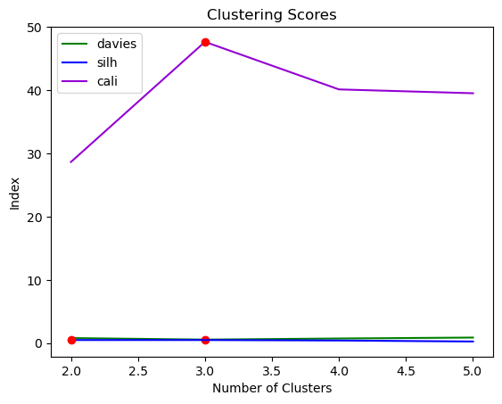

```python
# оцінюємо оптимальну кількість кластерів на основі індексів якості кластеризації
# для Calinski–Harabasz та Silhouette індекс має бути максимальним, для Davies–Bouldin - мінімальним

k_range = range(2, 6)  # 2, 3, 4, 5 кластерів
scores = {davies_bouldin_score: np.argmin, silhouette_score: np.argmax, calinski_harabasz_score: np.argmax}

handles=[]

for score, color in zip(scores.keys(), ['green', 'blue', 'darkviolet']):
    indices = []
    for k in k_range:
        labels = AgglomerativeClustering(n_clusters=k, linkage='ward').fit_predict(X)
        indices.append(score(X, labels))
    plt.plot(k_range, indices, color=color)
    arg = scores[score](indices)
    plt.plot(k_range[arg], indices[arg], marker='o', c='r')
    handles.append(plt.Line2D([], [], color=color))
    indices.append(score.__name__)

plt.title('Clustering Scores')
plt.xlabel('Number of Clusters')
methods = ["davies", "silh", "cali"]
plt.ylabel('Index')
plt.legend(handles, methods)
plt.show()
```

Як бачимо з результатів оцінки на основі індексів, найкраще підходить розбиття на 3 кластери.

Параметр average (середнє) використовує середнє значення відстаней кожного спостереження наборів даних.

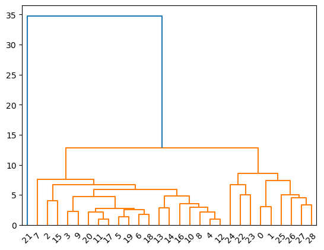

```python
#для побудови дендрограми використовуємо функцію dendrogram з модулю scipy.cluster.hierarchy
dendrogram(linkage(X, method='average'));
```

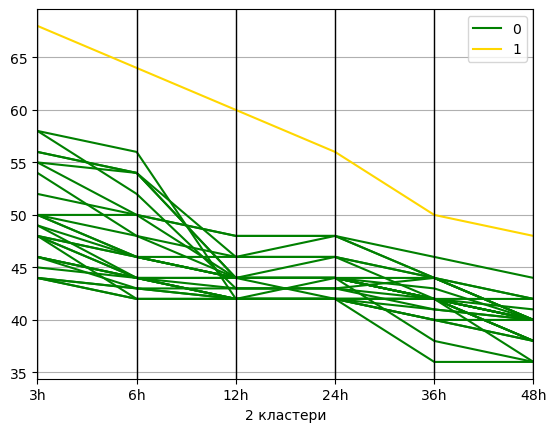

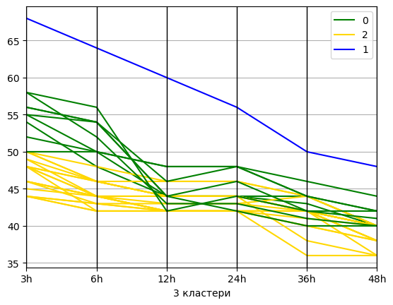

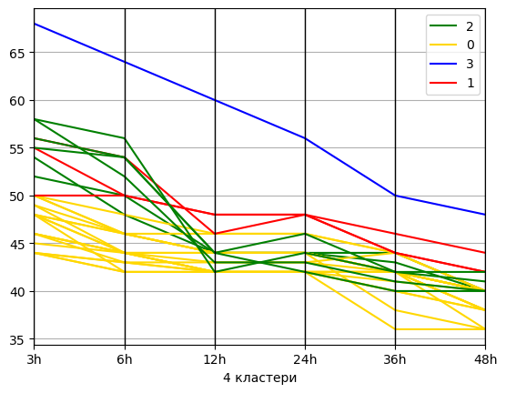

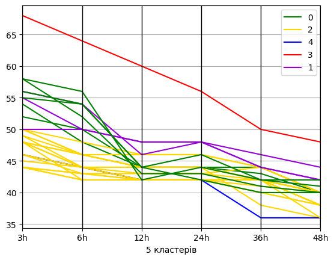

```python
#кластеризація алгоритмом AgglomerativeClustering з linkage = average
#розбиваємо на 2, 3, 4, 5 кластерів

#2 кластери
agglo = AgglomerativeClustering(n_clusters=2,linkage='average')
agglo.fit(X)
df['y_agglo'] = agglo.labels_ #мітки кластерів
colors = ('green', 'gold', 'blue', 'red', 'darkviolet')
pd.plotting.parallel_coordinates(df, 'y_agglo', cols=X.columns, color=colors)
plt.xlabel('2 кластери')
plt.show()

df_agglo_6 = df['y_agglo'] #записуємо результат для подальшого порівняння

#3 кластери
agglo = AgglomerativeClustering(n_clusters=3,linkage='average')
agglo.fit(X)
df['y_agglo'] = agglo.labels_ #мітки кластерів
colors = ('green', 'gold', 'blue', 'red', 'darkviolet')
pd.plotting.parallel_coordinates(df, 'y_agglo', cols=X.columns, color=colors)
plt.xlabel('3 кластери')
plt.show()

df_agglo_7 = df['y_agglo']

#4 кластери
agglo = AgglomerativeClustering(n_clusters=4,linkage='average')
agglo.fit(X)
df['y_agglo'] = agglo.labels_ #мітки кластерів
colors = ('green', 'gold', 'blue', 'red', 'darkviolet')
pd.plotting.parallel_coordinates(df, 'y_agglo', cols=X.columns, color=colors)
plt.xlabel('4 кластери')
plt.show()

df_agglo_8 = df['y_agglo']

#5 кластерів
agglo = AgglomerativeClustering(n_clusters=5,linkage='average')
agglo.fit(X)
df['y_agglo'] = agglo.labels_ #мітки кластерів
colors = ('green', 'gold', 'blue', 'red', 'darkviolet')
pd.plotting.parallel_coordinates(df, 'y_agglo', cols=X.columns, color=colors)
plt.xlabel('5 кластерів')
plt.show()

df_agglo_9 = df['y_agglo']
```

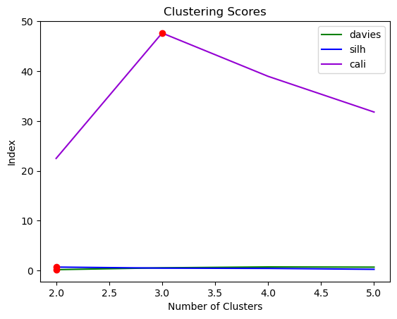

```python
# оцінюємо оптимальну кількість кластерів на основі індексів якості кластеризації
# для Calinski–Harabasz та Silhouette індекс має бути максимальним, для Davies–Bouldin - мінімальним

k_range = range(2, 6)  # 2, 3, 4, 5 кластерів
scores = {davies_bouldin_score: np.argmin, silhouette_score: np.argmax, calinski_harabasz_score: np.argmax}

handles=[]

for score, color in zip(scores.keys(), ['green', 'blue', 'darkviolet']):
    indices = []
    for k in k_range:
        labels = AgglomerativeClustering(n_clusters=k, linkage='average').fit_predict(X)
        indices.append(score(X, labels))
    plt.plot(k_range, indices, color=color)
    arg = scores[score](indices)
    plt.plot(k_range[arg], indices[arg], marker='o', c='r')
    handles.append(plt.Line2D([], [], color=color))
    indices.append(score.__name__)

plt.title('Clustering Scores')
plt.xlabel('Number of Clusters')
methods = ["davies", "silh", "cali"]
plt.ylabel('Index')
plt.legend(handles, methods)
plt.show()
```

Як бачимо з результатів оцінки на основі індексів, найкраще підходить розбиття на 2 кластери.

**4. Порівнюємо розбиття, одержані алгоритмом k-means та ієрархічним алгоритмом, співставляючи кластери. Використовуємо метод Rand Index для порівняння двох розбиттів.**

```python
#Rand Index реалізований як функція adjusted_rand_score у модулі sklearn.metrics
#розбиття на 2, 3, 4, 5 кластерів алгоритмом k-середніх та агломеративним зі зв'язками ward
print("kmeans vs linkage ward")
print()
print("2 кластери")
print(adjusted_rand_score(df_kmeans_2,df_agglo_2))
print("3 кластери")
print(adjusted_rand_score(df_kmeans_3,df_agglo_3))
print("4 кластери")
print(adjusted_rand_score(df_kmeans_4,df_agglo_4))
print("5 кластерів")
print(adjusted_rand_score(df_kmeans_5,df_agglo_5))
```

```
kmeans vs linkage ward

2 кластери
1.0
3 кластери
0.8670595939751146
4 кластери
0.7496114660680366
5 кластерів
0.39868555031009906
```

Найкращий результат відповідно до алгоритму Rand Index має розбиття на 2 кластери (1).

```python
#розбиття на 2, 3, 4, 5 кластерів алгоритмом k-середніх та агломеративним зі зв'язками average
print("kmeans vs linkage average")
print()
print("2 кластери")
print(adjusted_rand_score(df_kmeans_2,df_agglo_6))
print("3 кластери")
print(adjusted_rand_score(df_kmeans_3,df_agglo_7))
print("4 кластери")
print(adjusted_rand_score(df_kmeans_4,df_agglo_8))
print("5 кластерів")
print(adjusted_rand_score(df_kmeans_5,df_agglo_9))
```

```
kmeans vs linkage average

2 кластери
0.061488673139158574
3 кластери
0.8670595939751146
4 кластери
0.7001550921936929
5 кластерів
0.4501080926210507
```

Найкращий результат відповідно до методу Rand Index має розбиття на 3 кластери (0,867).